# Start codon context for Schizosaccharomyces pombe

Edward Wallace, ewjwallace@gmail.com

16 Jan 2019

# Summary

This presents the analysis of Schizosaccharomyces start codon usage and context. This uses the S. pombe 972h- translation estimates from Duncan and Mata 2017.

# Here we go

## Expression: RNA abundance and ribosome-protected-fragments

### Load expression data

We remove the Sp mitochondrial genes here because their translation is not detected by this ribosome profiling protocol.

```
## # A tibble: 5,164 x 7
##    Gene           RNA    RPF RNA_noN RPF_noN    TE TE_noN
##    <chr>        <dbl>  <dbl>   <dbl>   <dbl> <dbl>  <dbl>
##  1 SPCC1223.02  5846. 20301.   3169.   9560.  3.47   3.02
##  2 SPBC32F12.11 4811. 19320.   2608.   6422.  4.02   2.46
##  3 SPAC26F1.06  4038. 15032.   1452.   3782.  3.72   2.60
##  4 SPBC26H8.01  2817. 13956.   1570.   7698.  4.95   4.90
##  5 SPBC1815.01  3548. 12258.   1109.   1691.  3.45   1.53
##  6 SPAC27E2.11c 8220. 11694.   9323.  20023.  1.42   2.15
##  7 SPCC13B11.01 2772. 10487.   1367.   3940.  3.78   2.88
##  8 SPBC14F5.04c 2795.  9607.    889.   1815.  3.44   2.04
##  9 SPBC19C2.07  4923.  9148.   3135.   4251.  1.86   1.36
## 10 SPAC1F8.07c  3399.  8582.   1333.   2159.  2.53   1.62
## # ... with 5,154 more rows
```

#### Check replicability

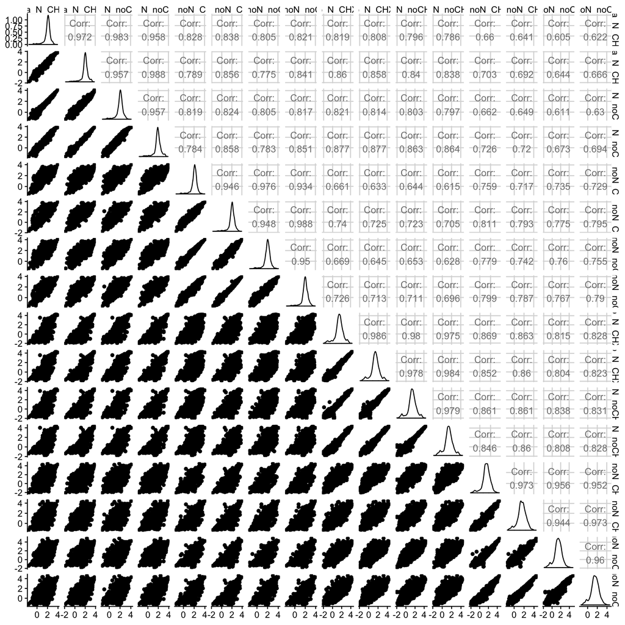

### Ribosome occupancy mostly tracks RNA abundance

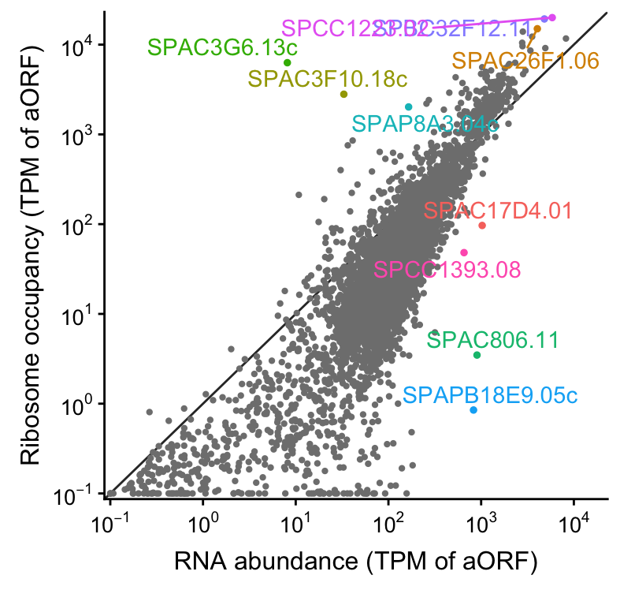

## ATG Context

### Load context data

```
## # A tibble: 5,118 x 19
##    Gene  aATG.context aATG.pos d1.context d1.posTSS d1.posATG d1.frame
##    <chr> <chr>           <dbl> <chr>          <dbl>     <dbl>    <dbl>
##  1 SPAC… ATTTCTACTGC…        1 AGATATCGC…        60        59        2
##  2 SPAC… ACGATTATAAG…      159 TTTAGTCCG…       266       107        2
##  3 SPAC… CAGTTTTTAGA…       61 CAGCAACTG…        85        24        0
##  4 SPAC… AAAAAAAAAAA…      339 GTAATAAGA…       376        37        1
##  5 SPAC… CTTAGCTATAA…      326 ACCGTCGAA…       371        45        0
##  6 SPAC… TTTCAATCCAA…      140 CCATTCCTC…       336       196        1
##  7 SPAC… AACTAATTCAA…      199 CTGCAGAGT…       236        37        1
##  8 SPAC… AAGTAGGAAAG…       72 GCAAAAAAC…       176       104        2
##  9 SPAC… TTTCCATCCAA…        1 AACAGCCCG…        29        28        1
## 10 SPAC… TCTTGTTAAAT…      315 TTAGAAATA…       364        49        1
## # ... with 5,108 more rows, and 12 more variables: d2.context <chr>,
## #   d2.posTSS <dbl>, d2.posATG <dbl>, d2.frame <dbl>, u1.context <chr>,
## #   u1.posTSS <dbl>, u1.posATG <dbl>, u1.frame <dbl>, u2.context <chr>,
## #   u2.posTSS <dbl>, u2.posATG <dbl>, u2.frame <dbl>
```

### Some genes are not in both context and ribosum data

```
## [1] "old_SPAC1556.06.2%2CSPAC1556.06" "old_SPAC2F3.13c%2CSPAC2F3"
```

```
##  [1] "SPAC14C4.09"   "SPAC1556.06.1" "SPAC1556.06.2" "SPAC212.05c"
##  [5] "SPAC212.07c"   "SPAC212.09c"   "SPAC212.10"    "SPAC23A1.20"
##  [9] "SPAC23D3.05c"  "SPAC2E12.05"   "SPAC2F3.12c"   "SPAC2F3.13c"
## [13] "SPAC750.08c"   "SPAC977.01"    "SPAC977.13c"   "SPAPB24D3.05c"
## [17] "SPBC1348.11"   "SPBC1706.02c"  "SPBC18E5.15"   "SPBC1E8.04"
## [21] "SPBC31A8.02"   "SPBC460.01c"   "SPBC460.02c"   "SPBC460.03"
## [25] "SPBC460.04c"   "SPBC460.05"    "SPBCPT2R1.05c" "SPBCPT2R1.06c"
## [29] "SPBCPT2R1.07c" "SPBCPT2R1.10"  "SPBPB10D8.03"  "SPBPB21E7.06"
## [33] "SPBPB21E7.08"  "SPCC132.05c"   "SPCC1450.01c"  "SPCC1494.11c"
## [37] "SPCC188.10c"   "SPCC18B5.02c"  "SPCC548.02c"   "SPCC576.16c"
## [41] "SPCC622.17"    "SPCC663.07c"   "SPCC830.02"    "SPCP20C8.03"
## [45] "SPMTR.01"      "SPMTR.02"      "SPMTR.03"      "SPMTR.04"
```

### Annotated ATGs have a Kozak consensus sequence

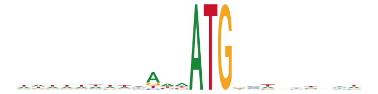

### Highly translated Annotated ATGs have a Kozak consensus sequence

That’s for hiTrans, the top 5% (256) translated genes by RPF TPM.

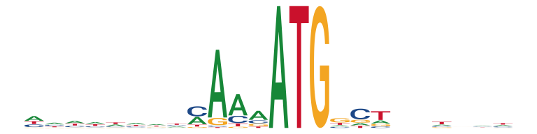

[figure not shown]

### Cytoplasmic Ribosome Annotated ATGs have a Kozak consensus sequence

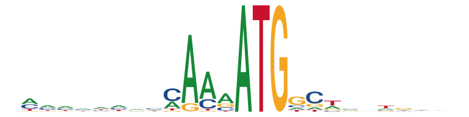

### Most cytoribo genes are highly translated (5% highest)

Venn diagram.

There are many duplicate cytoRibo genes in Sp.

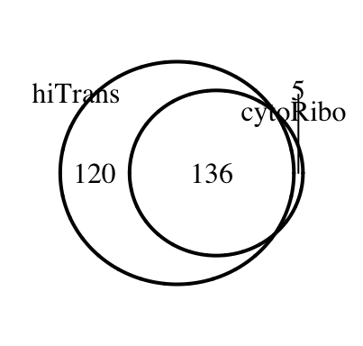

### Downstream ATGs don’t have a consensus

First downstream ATG

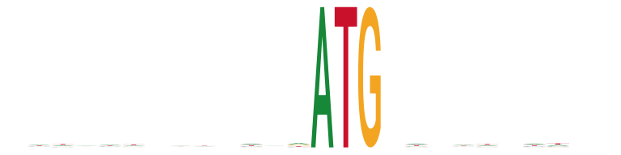

### Downstream ATGs in frame and highly translated don’t have a consensus

Except for 3rd-codon-position bias.

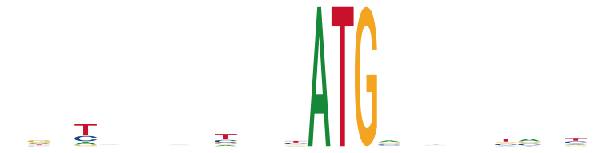

## Calculate Information content and scores of consensus motif

### Calculate a wide and a narrow consensus sequence

Calculate motif score against the position weight matrix (pwm) for both **narrow** (-4 from ATG through to ATG) and **wide** (-10 from ATG) kozak consensus motif. These motifs are taken from the top 5% highly translated genes.

### Estimate the information content

Using the sequence logo, details on https://en.wikipedia.org/wiki/Sequence_logo

```
## # A tibble: 6 x 4
##   Genes    ATG   Width   Infon
##   <chr>    <chr> <chr>   <dbl>
## 1 All      aATG  narrow 0.826
## 2 HiTrans  aATG  narrow 2.47
## 3 CytoRibo aATG  narrow 2.92
## 4 All      d1ATG narrow 0.182
## 5 HiTrans  d1ATG narrow 0.0885
## 6 CytoRibo d1ATG narrow 0.106
```

### Estimate information content per base across start context

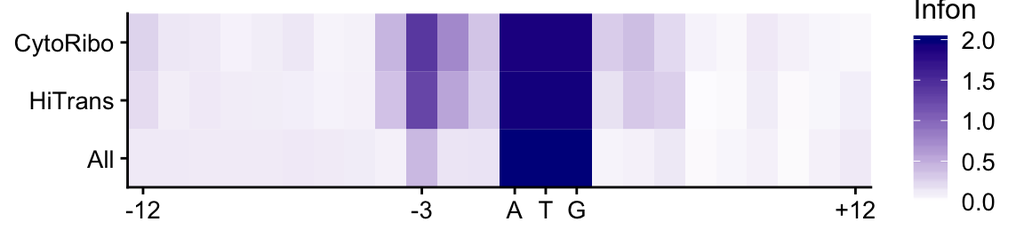

### Calculate scores of aATG, dATG, uATG against Kozak consensus

We calculate scores using Biostrings::PWMscoreStartingAt.

The best description I could find of this method is: https://support.bioconductor.org/p/61520/

It is just the sum of the matrix product of the PWM with the sequence.

Write scores to file *scores_kozak_Sp.txt*.

```
## # A tibble: 5,118 x 11
##    Gene  aATG.scorekn d1.scorekn u1.scorekn aATG.scorekw d1.scorekw
##    <chr>        <dbl>      <dbl>      <dbl>        <dbl>      <dbl>
##  1 SPAC…        0.816      0.756     NA            0.810      0.742
##  2 SPAC…        0.867      0.799      0.957        0.849      0.767
##  3 SPAC…        0.920      0.748     NA            0.891      0.722
##  4 SPAC…        0.938      0.887     NA            0.940      0.877
##  5 SPAC…        0.952      0.920      0.748        0.907      0.855
##  6 SPAC…        0.968      0.787     NA            0.944      0.792
##  7 SPAC…        0.948      0.848     NA            0.939      0.767
##  8 SPAC…        0.907      0.890      0.840        0.832      0.900
##  9 SPAC…        0.948      0.851     NA            0.911      0.798
## 10 SPAC…        0.898      0.887     NA            0.868      0.876
## # ... with 5,108 more rows, and 5 more variables: u1.scorekw <dbl>,
## #   d1vsan <dbl>, u1vsan <dbl>, d1vsaw <dbl>, u1vsaw <dbl>
```

### Plot against narrow consensus (-4 to ATG)

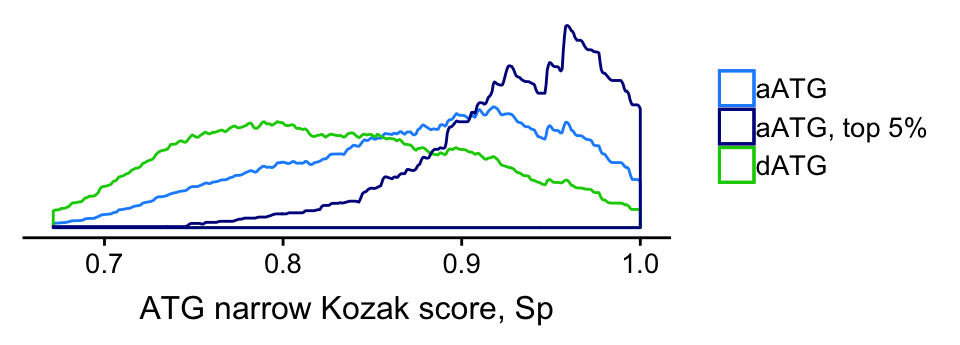

### Plot against wide consensus (-10 to ATG)

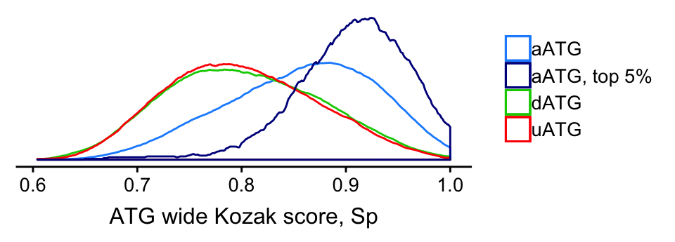

## Mutual information of different positions around ATG

### For all annotated genes

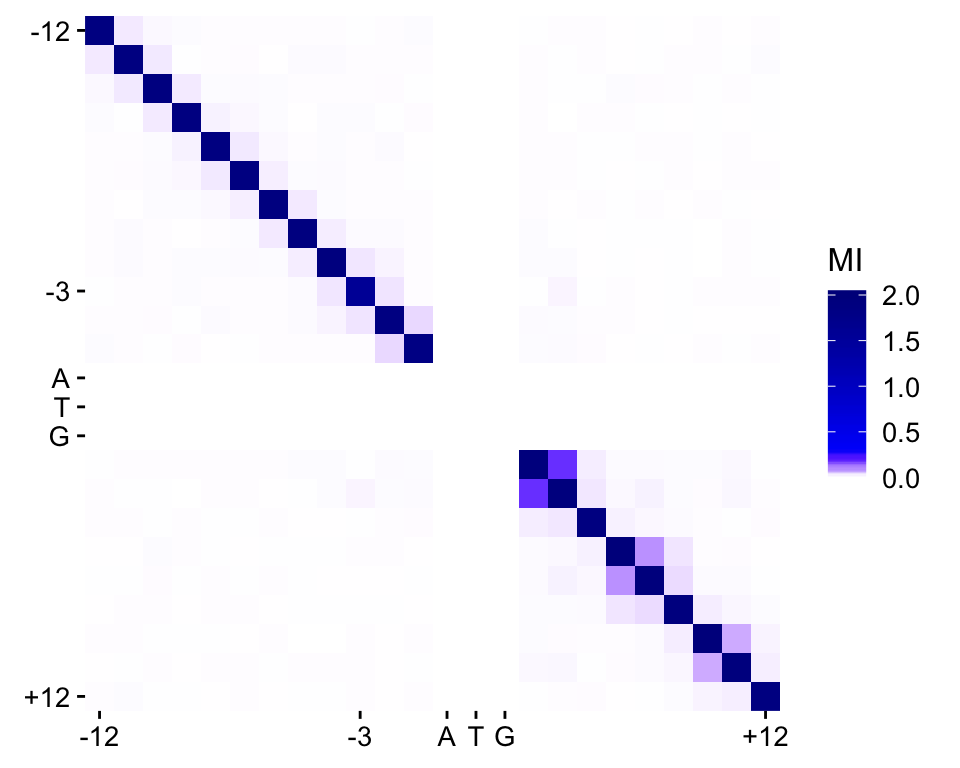

### For highly translated genes

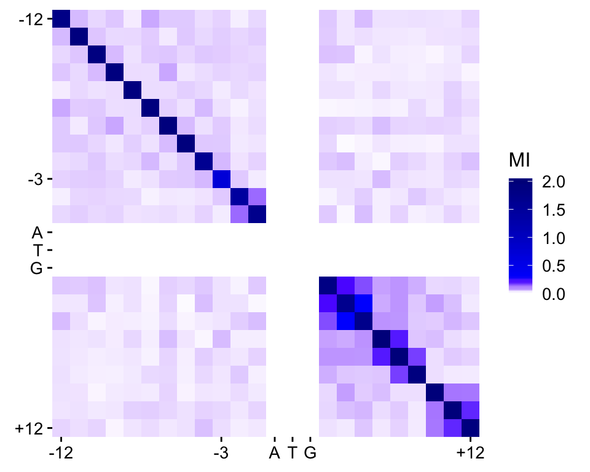

### For cytoplasmic ribosomal proteins

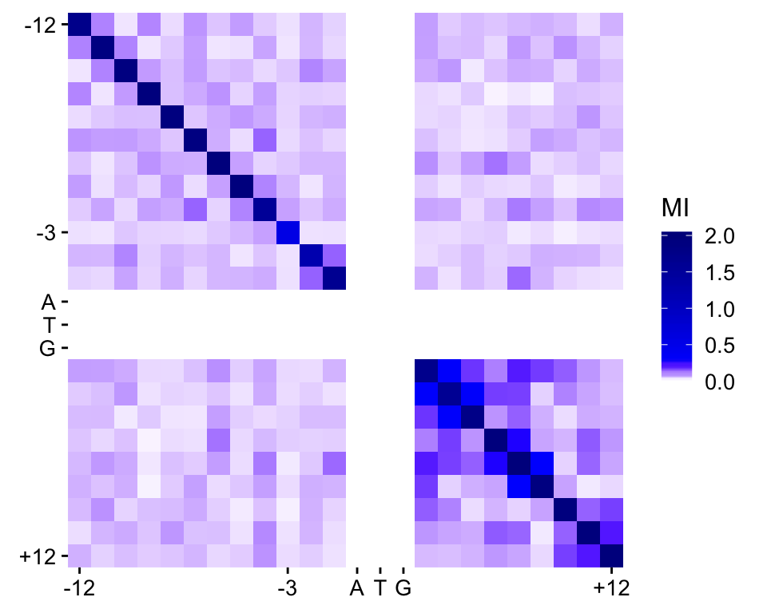

### What is the -2 correlation in cyto ribo genes?

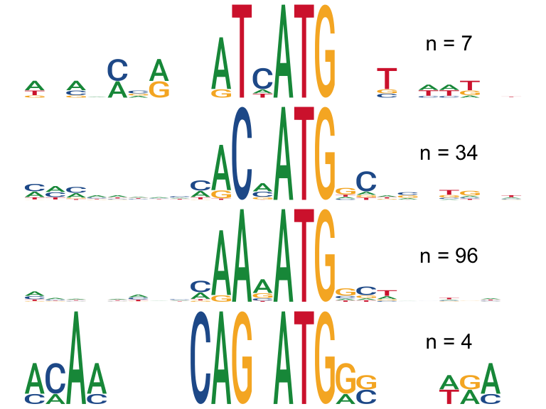

There are definitely correlations there.

## uATGs inhibit translation of the main ORF

### uATGs are associated with lower absolute translation

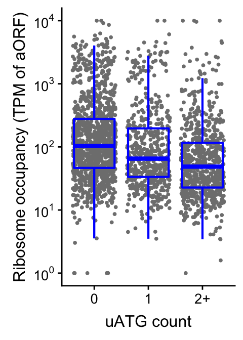

### uATGs are associated with lower translation efficiency

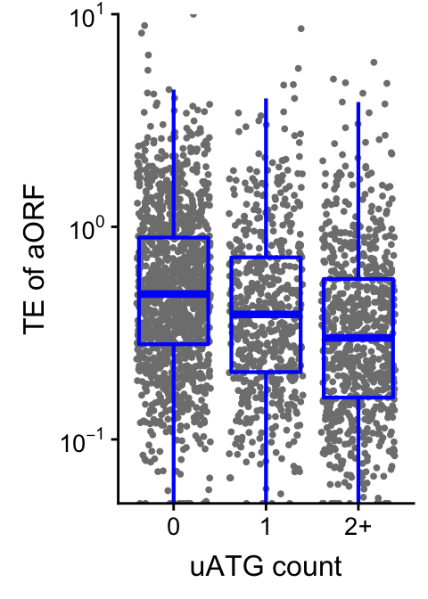

### uATGs associated with lower translation efficiency are over 20nt from TSS

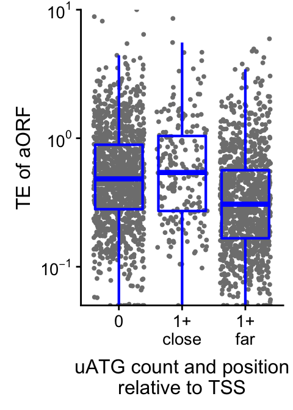

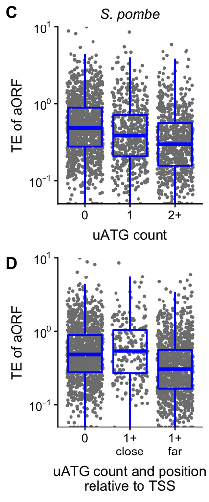

### uATG score does not strongly affect TE

We suspect that uATG is associated with lower TE if the uATG has

- position at least 20nt downstream from TSS
- higher score

This figure shows that, *for genes with only 1 uATG*, this correlation is weak and opposite to expected.

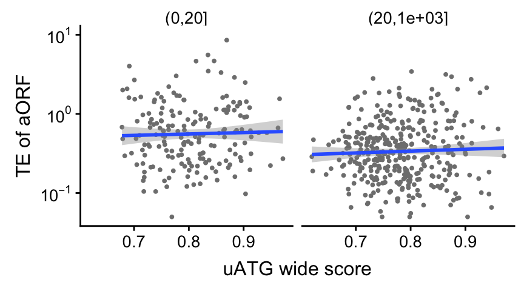

## Compare aATG and dATG context by gene

### Most dATG scores are less than aATG scores

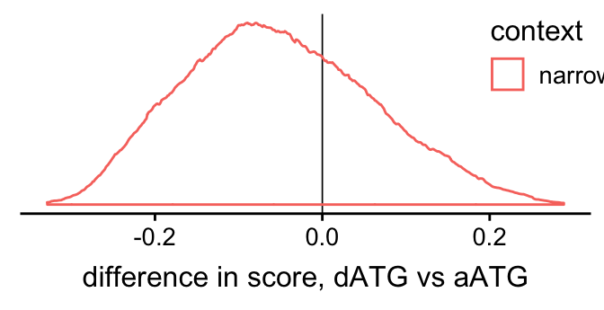

### For highly translated genes, most dATG narrow scores are much less than aATG

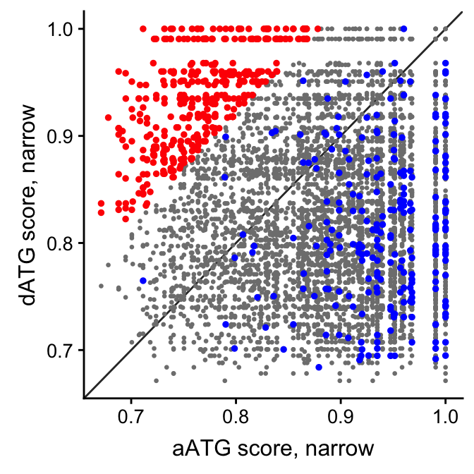

Red: high dATG vs aATG **Kozak** score. Blue: highly translated. Purple: both.

### Small negative correlation between dATG and aATG score narrow

R = -0.04

### For highly translated genes, most dATG wide scores are much less than aATG

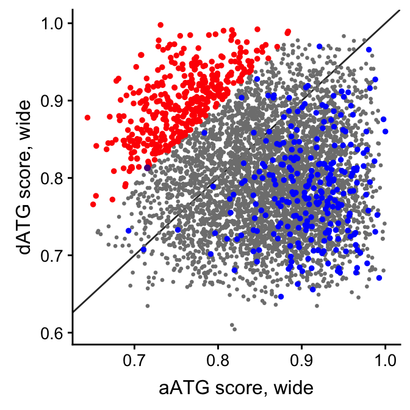

Red: high dATG vs aATG **Kozak** score. Blue: highly translated. Purple: both.

### Small negative correlation between dATG and aATG score wide

R = -0.043

## Genes with unusual dATG vs aATG narrow score

Those genes are in this list:

```
## # A tibble: 400 x 3
##    Gene          aATG.scorekn d1.scorekn
##    <chr>                <dbl>      <dbl>
##  1 SPCC1620.12c         0.711      1.000
##  2 SPBC9B6.11c          0.688      0.960
##  3 SPBC13G1.01c         0.722      0.991
##  4 SPAC222.04c          0.732      1.000
##  5 SPAC26F1.05          0.724      0.991
##  6 SPBC1289.10c         0.695      0.959
##  7 SPAC1F5.07c          0.738      1.000
##  8 SPAC1B2.06           0.740      1.000
##  9 SPAC12B10.01c        0.732      0.991
## 10 SPAC7D4.13c          0.734      0.991
## # ... with 390 more rows
```

- SPAC222.04c/Ies6, Ino80 chromatin remodeling complex subunit
- SPAC26F1.05/Mug106, meiotically upregulate, short, no known orthologs.
- SPCC1620.12c GTPase activating protein, distand MDR1/GYP2 homolog
- SPBC9B6.11c CCR4/nocturin family endoribonuclease, NGL2/3 homolog
- SPAC12B10.01c HECT-type ubiquitin-protein ligase E3, UFD4 homolog
- SPAC1B2.06, short, no known orthologs

Some of these are decently translated (top 25%)

```
## # A tibble: 32 x 3
##    Gene         aATG.scorekn d1.scorekn
##    <chr>               <dbl>      <dbl>
##  1 SPCC1672.02c        0.738      0.960
##  2 SPBC2G2.12          0.692      0.905
##  3 SPBC1198.08         0.724      0.935
##  4 SPAC3H1.05          0.750      0.952
##  5 SPBC25H2.16c        0.812      1.000
##  6 SPAC1565.08         0.747      0.934
##  7 SPBC1677.03c        0.724      0.908
##  8 SPBC146.13c         0.711      0.887
##  9 SPBC11C11.05        0.764      0.934
## 10 SPBC582.03          0.787      0.957
## # ... with 22 more rows
```

- SPCC31H12.08c CCR4-Not complex subunit Ccr4
- SPBC13G1.01c mitochondrial ribosomal protein subunit S4
- SPCC188.04c NMS complex subunit Spc25
- SPBC1198.08 dipeptidase Dug1
- SPAC1071.01c mRNA cleavage and polyadenylation specificity factor complex subunit Pta1
- SPAC22F3.06c Lon protease homolog Lon1 (mito localized)
- SPBC428.01c nucleoporin Nup107
- SPBC3F6.04c U3 snoRNP protein Nop14

Several things involved in mRNA 3’ end regulation. Otheriwse unclear. We should check if those ATGs are actually used.

### dATG in frame with ATG, narrow

Files with high difference in narrow score, filtered for top 50% of RNA, in frame. Saved to *dvsaATG_highdiffn_inframe_Sp.txt*.

```
## # A tibble: 30 x 3
##    Gene          aATG.scorekn d1.scorekn
##    <chr>                <dbl>      <dbl>
##  1 SPBC9B6.11c          0.688      0.960
##  2 SPAC12B10.01c        0.732      0.991
##  3 SPAC3G6.04           0.754      0.991
##  4 SPBC428.01c          0.701      0.925
##  5 SPCC1672.02c         0.738      0.960
##  6 SPBC2G2.12           0.692      0.905
##  7 SPBC1198.08          0.724      0.935
##  8 SPBP35G2.14          0.692      0.896
##  9 SPAC3F10.05c         0.732      0.935
## 10 SPAC3H1.05           0.750      0.952
## # ... with 20 more rows
```

### dATG out of frame with ATG, narrow

Files with high difference in narrow score, filtered for top 50% of RNA, out of frame. Saved to *dvsaATG_highdiffn_outframe_Sp.txt*.

```
## # A tibble: 127 x 3
##    Gene          aATG.scorekn d1.scorekn
##    <chr>                <dbl>      <dbl>
##  1 SPBC13G1.01c         0.722      0.991
##  2 SPAC222.04c          0.732      1.000
##  3 SPBC1289.10c         0.695      0.959
##  4 SPAC11E3.01c         0.738      0.991
##  5 SPCC31H12.08c        0.721      0.968
##  6 SPAC1071.01c         0.746      0.991
##  7 SPBC28F2.10c         0.758      1.000
##  8 SPCC663.10           0.750      0.991
##  9 SPCC1739.14          0.714      0.948
## 10 SPBC543.09           0.767      1.000
## # ... with 117 more rows
```

### dATG in frame with ATG, wide

Files with high difference in wide score, filtered for top 50% of RNA, in frame. Saved to *dvsaATG_highdiffw_inframe_Sp.txt*.

```
## # A tibble: 30 x 3
##    Gene          aATG.scorekw d1.scorekw
##    <chr>                <dbl>      <dbl>
##  1 SPAC12B10.01c        0.729      0.978
##  2 SPBC9B6.11c          0.681      0.928
##  3 SPAC1565.08          0.690      0.907
##  4 SPAC3F10.05c         0.715      0.929
##  5 SPBC1198.08          0.699      0.910
##  6 SPAC3G6.04           0.750      0.958
##  7 SPBC428.01c          0.706      0.912
##  8 SPBC11C11.05         0.714      0.902
##  9 SPBC146.12           0.654      0.841
## 10 SPAC57A7.12          0.740      0.901
## # ... with 20 more rows
```

### dATG out of frame with ATG, wide

Files with high difference in wide score, filtered for top 50% of RNA, out of frame. Saved to *dvsaATG_highdiffw_outframe_Sp.txt*.

```
## # A tibble: 128 x 3
##    Gene          aATG.scorekw d1.scorekw
##    <chr>                <dbl>      <dbl>
##  1 SPAC222.04c          0.731      0.998
##  2 SPAC11E3.01c         0.708      0.959
##  3 SPBC1703.02          0.678      0.925
##  4 SPBC13G1.01c         0.759      0.967
##  5 SPCC31H12.08c        0.705      0.910
##  6 SPAC29E6.03c         0.717      0.913
##  7 SPAC1071.01c         0.723      0.918
##  8 SPAC10F6.17c         0.733      0.924
##  9 SPCC1739.14          0.728      0.919
## 10 SPBC25H2.16c         0.807      0.990
## # ... with 118 more rows
```

## Compare score difference to localization predictions

### Load predictions from mitofates

In input file *SPombe_mitofates.txt*.

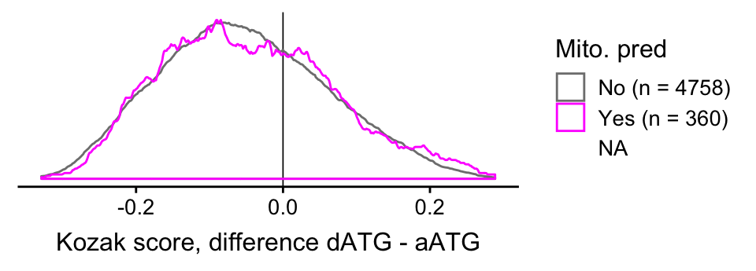

### Correlations between d1 score, d1 frame, and localization

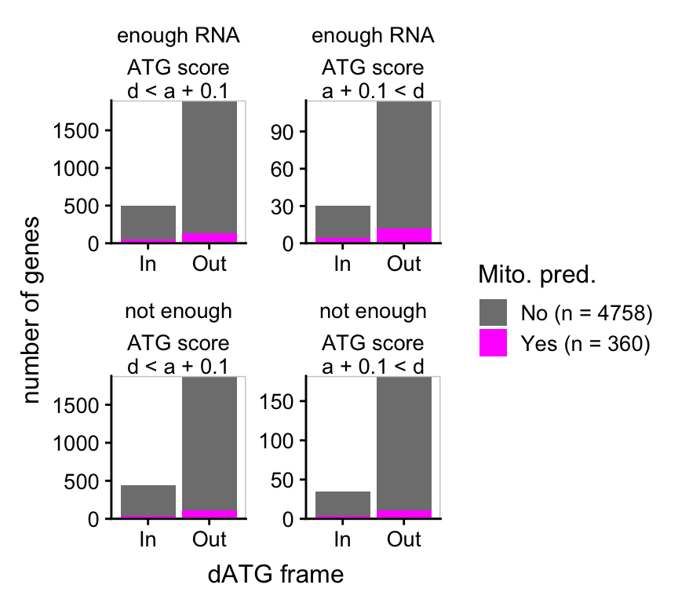

### Count dATG vs ATG score, d1 frame, mito pre, enough RNA

```
## # A tibble: 16 x 5
## # Groups:   enoughR, d1vsaw0p1, d1.framefac [?]
##    enoughR d1vsaw0p1 d1.framefac Pred_preseq     n
##    <fct>   <fct>     <fct>       <fct>       <int>
##  1 Yes     d1lo      In          No            451
##  2 Yes     d1lo      In          Yes            51
##  3 Yes     d1lo      Out         No           1765
##  4 Yes     d1lo      Out         Yes           132
##  5 Yes     d1hi      In          No             26
##  6 Yes     d1hi      In          Yes             4
##  7 Yes     d1hi      Out         No            103
##  8 Yes     d1hi      Out         Yes            12
##  9 No      d1lo      In          No            403
## 10 No      d1lo      In          Yes            34
## 11 No      d1lo      Out         No           1770
## 12 No      d1lo      Out         Yes           108
## 13 No      d1hi      In          No             31
## 14 No      d1hi      In          Yes             4
## 15 No      d1hi      Out         No            171
## 16 No      d1hi      Out         Yes            11
```

### Sp mito-localized genes also do not have a distinctive aATG context

Although the +5 T is striking.

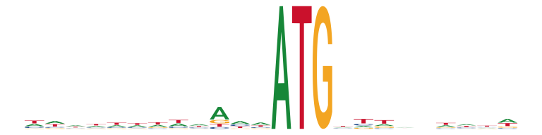

## Genes with unusual dATG vs aATG narrow score AND predicted mito loc

Those genes are in this list:

```
## # A tibble: 31 x 9
##    Gene  aATG.scorekn d1.scorekn d1.frame d1.posATG   RNA    RPF RNA_noN
##    <chr>        <dbl>      <dbl>    <dbl>     <dbl> <dbl>  <dbl>   <dbl>
##  1 SPBC…        0.722      0.991        2       128 144.   48.5     92.0
##  2 SPCC…        0.748      1.000        1        31  69.7   2.57    53.9
##  3 SPAP…        0.701      0.951        2        80  85.9  12.3     37.4
##  4 SPBC…        0.767      1.000        1       274 196.   51.7    215.
##  5 SPBC…        0.778      1.000        0       216  50.3  19.1     44.5
##  6 SPBC…        0.769      0.991        1        10 232.   30.6    121.
##  7 SPCC…        0.769      0.991        2        56  66.0   2.76    78.3
##  8 SPBC…        0.701      0.917        2        62 134.   43.6    118.
##  9 SPBC…        0.692      0.905        0        75 264.  173.     118.
## 10 SPBC…        0.757      0.966        0        24  92.7  26.9     90.6
## 11 SPAC…        0.748      0.952        2       122 311.   44.3    355.
## 12 SPAC…        0.715      0.912        2        71  53.9   3.03    62.8
## 13 SPBC…        0.758      0.951        2        86  64.7   3.47    21.6
## 14 SPBC…        0.724      0.908        2        95 394.  149.     275.
## 15 SPBC…        0.711      0.887        1        73 280.   88.4    466.
## 16 SPAC…        0.831      1.000        1        49  90.6  23.1    112.
## 17 SPAC…        0.732      0.900        0         3 331.  272.     694.
## 18 SPBC…        0.722      0.890        0        39 117.   41.2    111.
## 19 SPBC…        0.743      0.908        2        68 184.   73.5    225.
## 20 SPBC…        0.722      0.881        2         5  80.4   4.74    57.3
## 21 SPAC…        0.790      0.948        2       104 112.   33.8     98.5
## 22 SPAP…        0.764      0.920        2        77  38.2  12.3     93.8
## 23 SPBC…        0.755      0.908        2        68  84.9  18.4     88.3
## 24 SPAC…        0.707      0.859        1        73  90.1   9.58    92.5
## 25 SPCC…        0.780      0.930        2        41  69.8   2.94    24.9
## 26 SPAC…        0.688      0.837        0        42  58.5  11.4     43.0
## # ... with 5 more rows, and 1 more variable: RPF_noN <dbl>
```

- SPBC13G1.01c mitochondrial ribosomal protein subunit S4
- SPBC9B6.11c CCR4/nocturin family endoribonuclease, NGL2/3 homolog
- SPAPB1A10.11c mitochondrial glutamyl-tRNA ligase Mse1
- SPCC1183.04c mitochondrial RNA metabolism pathway protein Pet127
- SPAC22F3.06c Lon1
- SPBC1347.07 RNA exonuclease Rex2, processes RNA in nuc and mito, multiple differentially localized paralogs in Scer.
- SPBC3F6.04c U3 snoRNP protein Nop14
- SPBC16E9.06c BolA domain UV induced protein Uvi31
- SPBC146.12 monooxygenase Coq6
- SPBC3D6.03c mitochondrial 3’-tRNA processing endonuclease tRNAse Z, Trz2, mito ortholog of Trz1, and Trz1 is dual-localized in Scer.
- SPBC16A3.14 superoxide dismutase, mitochondrial ribosomal protein subunit
- SPBC543.09 mitochondrial m-AAA protease Yta12
- SPBC2G2.12 mitochondrial and cytoplasmic histidine-tRNA ligase Hrs1
- SPBC1539.01c mitochondrial ribosomal protein subunit L15 Mrp15
- SPAC4A8.03c protein phosphatase 2C Ptc4
- SPBC1677.03c threonine ammonia-lyase Tda1. Scer paralogs ILV1 (mito) and SRY1 (loc not known)
- SPBC146.13c myosin type I
- SPAC1B3.04c mitochondrial elongation factor GTPase Guf1
- SPAC6C3.04 citrate synthase Cit1. Scer has two paralogs, Cit1 (mito) and Cit2 (cyto/peroxisomal). But here the 2nd ATG is right next to the first ATG so that’s probably just an annotaion off by 1.
- SPBC15C4.02 ABC1 kinase family protein, implicated in mito activity, Mcp2 homolog

Histidine tRNA Ligase, Hurrah!

Several mitochondrial ribosomal proteins, check these.

### less strong biases, but in frame dATG

```
## # A tibble: 94 x 8
##    Gene    aATG.scorekn d1.scorekn d1.posATG   RNA     RPF RNA_noN RPF_noN
##    <chr>          <dbl>      <dbl>     <dbl> <dbl>   <dbl>   <dbl>   <dbl>
##  1 SPBC13…        0.778      1.000       216  50.3 1.91e+1    44.5 1.52e+1
##  2 SPBC2G…        0.692      0.905        75 264.  1.73e+2   118.  6.19e+1
##  3 SPBC16…        0.757      0.966        24  92.7 2.69e+1    90.6 2.46e+1
##  4 SPAC6C…        0.732      0.900         3 331.  2.72e+2   694.  7.98e+2
##  5 SPBC14…        0.722      0.890        39 117.  4.12e+1   111.  4.75e+1
##  6 SPAC3H…        0.688      0.837        42  58.5 1.14e+1    43.0 1.36e+1
##  7 SPBC2G…        0.738      0.870         9 172.  3.27e+1    69.1 7.11e+0
##  8 SPBC60…        0.758      0.868        84  23.6 1.69e+0    22.4 3.39e+0
##  9 SPAC24…        0.786      0.891         3  73.5 9.73e+0    90.9 1.57e+1
## 10 SPAC23…        0.763      0.864        36 176.  1.01e+2   231.  1.76e+2
## 11 SPAC57…        0.819      0.917        18  14.2 3.19e-1    13.7 4.68e-1
## 12 SPBC21…        0.760      0.852         3 208.  1.07e+2   221.  1.95e+2
## 13 SPBC2G…        0.864      0.952       105 794.  1.62e+3  1170.  2.54e+3
## 14 SPBC12…        0.795      0.878        60  97.4 9.91e+1   237.  3.49e+2
## 15 SPBC21…        0.925      1.000         9 259.  8.78e+1   335.  1.90e+2
## 16 SPAC4F…        0.917      0.991        60 169.  3.94e+1   162.  3.60e+1
## 17 SPCC16…        0.731      0.790        54  66.4 3.86e+2    72.9 7.99e+2
## 18 SPBC88…        0.779      0.838        60 136.  1.44e+1   148.  1.33e+1
## 19 SPBC16…        0.935      0.991        42 375.  7.17e+1   322.  4.96e+1
## 20 SPBP8B…        0.824      0.878        21  90.8 2.63e+1    51.1 1.78e+1
## # ... with 74 more rows
```

- SPBC2G2.08 ade9 C-1-tetrahydrofolatesynthase &c, Scer has MIS1 (mito) & ADE3 (cyto) homologs. Predicted cleavage site is 12aas in.
- SPBC21C3.04c mitochondrial ribosomal protein subunit L34, but ATGATG
- SPAC3H1.10 phytochelatin synthetase
- SPAC4F8.02c mitochondrial ribosomal protein subunit L40
- SPAC23C11.17 mdm28 mitochondrial inner membrane protein potassium transport
- SPAC26F1.14c apoptosis-inducing factor homolog Aif1, orthologs dual-localized? No Scer homolog.
- SPBC1861.05 pseudouridine-metabolizing bifunctional protein.
- SPBC2G2.04c mitochondrial matrix protein, YjgF family protein Mmf1, Scer has mito (MMF1) and cyto (HMF1) paralogs.
- SPCC1682.01 qcr9 ubiquinol-cytochrome-c reductase complex subunit 9

Some are dual-localized.

Predict that *many* more of the dual-localized things, such as aa-tRNA-synthetases, have non-ATG starts.

Back to table of contents